# Goals of this Notebook

- Acquiring data from text files with Python
- Structuring data in Python variables that facilitate various analyses
- Gain experience with for loops
- Gain expertise in structuring data within multidimensional data structures

Business analytics professionals must know how to access data programmatically and structure such that it suits the requirements of the intended methodology This session helps develop this skill using basic Python commands.

Acquiring and structuring data within Python variables requires loops, and so this material relies heavily on loops.

Later, you will often use the numpy and pandas packages to ease data acquisition and structuring. These packages, however, hide the details from you which are very important to know. for example, numpy and pandas does the operations we will demonstrate *under the covers* and you will not be able to troubleshoot problems with those packages unless you understnad the basics. It is important, therefore, to practice these computations with loop statements that we explicitly write which gives you the essential insight into what the more advanced programming statements are doing.

Whenever lists or dictionaries are created with for loops, it is natural to think about doing so more succinctly using list comprehension and dictionary comprehension, respectively. We will cover these alternate methods in this session, as well.

This material also prepares you with the skills and context for subsequent courses so that you can get the most out of them.

# Python Methods in this Notebook

- Text file data input with open() statement
- for loops
- List comprehension
- Dictionary comprehension

# Skills Refresher Navigation

- Go to for loops
- Go to List Comprehension
- Go to Dictionaries
- Go to Looping through dictionaries
- Go to Dictionary Comprehension
- Go to Aliasing

# Handling Data with Basic Python

Back to Navigation

## 1D Data: Times Series Analysis

First, time series data are data that are collected over time at constant intervals. Examples include, daily or hourly weather data, daily sales of an item or all company sales in total (either in units or dollar volume), number of daily visits to a web site, and annual gross domestic product. You can surely think of other examples.

One issue that arises with time series data is to summarize the pattern over time despite there being frequent highs and lows (noise) and highs and lows over longer periods (either economic cycles or seasonal effects). Computing the moving average is a frequently used method for summarizing the trend that is muddied by the short-term noise.

Let our time series data be collected for time indices $d \in \left\lbrace 0, ... , D-1 \right\rbrace$, where $d$ stands for the index for a given day. We will be considering daily time series for a year, so $D=365$. A moving average, $ma_n(d)$ of $n$ days for day $d$ is defined as:

$ma_n(d) = \frac{1}{n} \Sigma_{i = d-n+1}^d t(i)$

where $t(d)$ is the average temperature for day $d$. Note that $ma(d)$ is defined only for day in this range: $d \in \left\lbrace n-1, \ldots , D-1 \right\rbrace$.

The files NorfolkWeather1999.csv and NorfolkWeather2018.csv have the daily average temperatures for the years indicated in the filenames. Load each of these text files into a list (load only the daily average temperature and not the row index), and then create new lists, ma1999 and ma2018, that are 10-day moving averages of the original data.

Although we are not focusing on plotting in this session, we will compare the two moving average series using the matplotlib package.

Let's read the 1999 data file first.

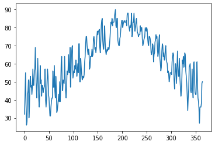

```python
%matplotlib inline
import matplotlib.pyplot as plt

f = open('NorfolkWeather1999.csv','r')
nw1999 = f.readlines()
f.close()

for i in range(len(nw1999)):
    nw1999[i] = nw1999[i].strip()
    nw1999[i] = nw1999[i].split(',')
    nw1999[i] = float(nw1999[i][1])
#nw1999 = list(map(float,nw1999))

plt.plot(nw1999, label = '1999')
plt.show()

#nw1999
```

Now, read in the 2018 data.

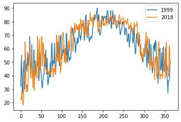

```python
f = open('NorfolkWeather2018.csv','r')
nw2018 = f.readlines()
f.close()

for i in range(len(nw2018)):
    nw2018[i] = nw2018[i].strip()
    nw2018[i] = nw2018[i].split(',')
    nw2018[i] = float(nw2018[i][1])
#nw2018 = list(map(float,nw2018))

""" Plot both data series """
plt.plot(nw1999, label = '1999')
plt.plot(nw2018, label = '2018')
plt.legend()
plt.show()
```

The two code blocks could be combined and the repetitive clean-up steps can be put into a function to clean up the code.

```python
def add1(x):
    x = x + 1
```

```python
def deleteEnd(myList):
    del myList[-1]
```

```python
z = 10
add1(z)
z
```

```
10
```

```python
thisList = [0,1,2]
deleteEnd(thisList)
thisList
```

```
[0, 1]
```

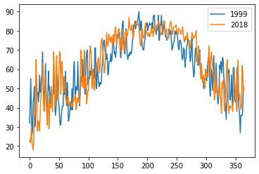

```python
def cleanup(x):
    for i in range(len(x)):
        """
        x[i] = x[i].strip()
        x[i] = x[i].split(',')
        """
        x[i] = float(x[i].strip().split(',')[1])
        #x[i] = float(x[i][1])
    #x = list(map(float,x))
    return x

f = open('NorfolkWeather1999.csv','r')
nw1999 = f.readlines()
f.close()

f = open('NorfolkWeather2018.csv','r')
nw2018 = f.readlines()
f.close()

nw1999 = cleanup(nw1999)
nw2018 = cleanup(nw2018)

plt.plot(nw1999, label = '1999')
plt.plot(nw2018, label = '2018')
plt.legend()
plt.show()

#nw1999
```

Now, compute and plot the moving averages of the two data series.

```python
sum(myList)
```

[output not shown]

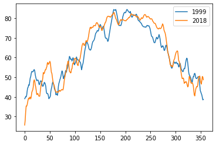

```python
n = 10

#ma1999 = []
#ma2018 = []

#for d in range(n,len(nw1999)+1):
#    ma1999.append(sum(nw1999[d-n:d])/n)
#    ma2018.append(sum(nw2018[d-n:d])/n)

ma1999 = [sum(nw1999[d-n:d])/n for d in range(n,len(nw1999)+1)]
ma2018 = [sum(nw2018[d-n:d])/n for d in range(n,len(nw2018)+1)]

plt.plot(ma1999, label = '1999')
plt.plot(ma2018, label = '2018')
plt.legend()
plt.show()

#ma2018
```

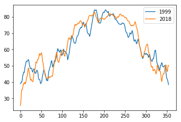

```python
# Open the files and inut the series into lists
period = 10

ma1999 = [sum(nw1999[i-period:i])/period for i in range(period,len(nw1999))]
ma2018 = [sum(nw2018[i-period:i])/period for i in range(period,len(nw2018))]

plt.plot(ma1999, label = '1999')
plt.plot(ma2018, label = '2018')
plt.legend()
plt.show()
```

## 2D Data: Markov Analysis of Customer Retention

Back to Navigation

Companies believe it is less costly to keep a customer than to acquire a new one. Companies are, therefore, interested in understanding customers buying patterns, analyzing how long a customer is likely to continue buying from them, and figuring out how to intervene in the customer lifecycle to prolong relationships with customers.

One might measure a customer's activity by selling season (if you worked for LL Bean), keeping track of whether a customer made a purchase from each season's catalog.

[figure not shown]

We can measure a customer's current level of activity by how many seasons it has been since their last purchase. In Markov processes we call this the customer's *state*. So, a customer's state is indicated by an integer from $0$ to $\infty$, which is the number of seasons since their last purchase. Practically, we don't need to consider any states past some number of $n$ seasons, where custoemrs who have not pruchased in $n$ seasons are unlikely to make another purchase from LL Bean again. We might consider customers who haven't made a purchase in the past $n$, for some appropritely sized $n$, to exhibit behaviors akin to a new customer rather than a current one.

We could determine the percentage of times that customers in each of these states made purchases and, conversely the percentage of times they did not: these proportions can be interpreted as the probabilities of, respectively, a customer's state transitioning to $0$ and increasing by one. These probabiltiies are typical represented in a *Transtiion Matrix*, as shown below. The notation $p_{x,y}$ represents the probability, or percentage of times, that customers in State $x$ transition to State $y$. Note that it makes sense for all probabilities in each row to sum to $1$. Why is that?

[figure not shown]

Let's read in transition matrix data from a text file (transMat.txt). In this file the greatest state is $n=5$. Pay attention to ensure that all the elements are converted to numerical quantities.

```python
""" Read the transition matrix file data into a list of lists with numerical elements """


''' Open text file and read '''
f = open('transMat.txt','r')
P = f.readlines()
f.close()

''' put in format that we can do computation '''
for i in range(len(P)):
    P[i] = P[i].strip().split(',')
    for j in range(len(P[i])):
        P[i][j] = float(P[i][j])

P
```

```
[[0.5, 0.5, 0.0, 0.0, 0.0, 0.0],
 [0.5, 0.0, 0.5, 0.0, 0.0, 0.0],
 [0.45, 0.0, 0.0, 0.55, 0.0, 0.0],
 [0.4, 0.0, 0.0, 0.0, 0.6, 0.0],
 [0.35, 0.0, 0.0, 0.0, 0.0, 0.65],
 [0.0, 0.0, 0.0, 0.0, 0.0, 1.0]]
```

```python
""" Read the transition matrix file data into a list of lists with numerical elements with list comprehension """

''' Open text file and read '''
f = open('transMat.txt','r')
P = f.readlines()
f.close()

''' put in format that we can do computation '''
for i in range(len(P)):
    P[i] = P[i].strip().split(',')

    #for j in range(len(P[i])):
    #    P[i][j] = float(P[i][j])

    P[i] = [float(P[i][j]) for j in range(len(P[i])) ]

P
```

```
[[0.5, 0.5, 0.0, 0.0, 0.0, 0.0],
 [0.5, 0.0, 0.5, 0.0, 0.0, 0.0],
 [0.45, 0.0, 0.0, 0.55, 0.0, 0.0],
 [0.4, 0.0, 0.0, 0.0, 0.6, 0.0],
 [0.35, 0.0, 0.0, 0.0, 0.0, 0.65],
 [0.0, 0.0, 0.0, 0.0, 0.0, 1.0]]
```

##### A Computation with the Transition Matrix

Let's represent our current customer base by a vector with each element representing the number of customers in each state, $s = \left\lbrace 0, 1, \ldots , 5 \right\rbrace$. Name a Python variable custNow to represent the population of customers in each category now and custNext to represent the expected number of customers in each category next period. How would you compute the expected number of customers in each of the states for next season, custNext? Perform the computation.

```python
custNow = [1024, 512, 256, 2048, 5092, 10184]

custNext = []

for j in range(len(P[0])):
    cum = 0
    for i in range(len(P)):
        cum = cum + custNow[i] * P[i][j]

    custNext.append(cum)
custNext
```

```
[3484.6, 512.0, 256.0, 140.8, 1228.8, 13493.8]
```

Perform the previous computation with list comprehension.

```python
sum(custNow)
```

```
19116
```

```python
custNow = [1024, 512, 256, 2048, 5092, 10184]

"""
custNext = []

for j in range(len(P[0])):
    cum = 0
    for i in range(len(P)):
        cum = cum + custNow[i] * P[i][j]

    custNext.append(cum)
"""
custNext = [sum([custNow[i] * P[i][j] for i in range(len(P))])   for j in range(len(P[0]))]
custNext
```

```
[3484.6, 512.0, 256.0, 140.8, 1228.8, 13493.8]
```

## Another Computation with the Transition Matrix

The transition matrix for two seasons in the future is the transition matrix multiplied by itself, that is, the dot product of $P$ with itself. Perform that calculation.

```python
P2 = []
for i in range(len(P)):
    newRow = []
    for j in range(len(P[0])):
        cum = 0
        for k in range(len(P)):
            cum += P[i][k] * P[k][j]
        newRow.append(cum)
    P2.append(newRow)
P2
```

```
[[0.5, 0.25, 0.25, 0.0, 0.0, 0.0],
 [0.475, 0.25, 0.0, 0.275, 0.0, 0.0],
 [0.44500000000000006, 0.225, 0.0, 0.0, 0.33, 0.0],
 [0.41000000000000003, 0.2, 0.0, 0.0, 0.0, 0.39],
 [0.175, 0.175, 0.0, 0.0, 0.0, 0.65],
 [0.0, 0.0, 0.0, 0.0, 0.0, 1.0]]
```

Perform the computation above with list comprehension.

```python
#P2 = []
#for i in range(len(P)):
#    newRow = []
#    for j in range(len(P[0])):
#        cum = 0
#        for k in range(len(P)):
#            cum += P[i][k] * P[k][j]
#        newRow.append(cum)
#    P2.append(newRow)


P2 =[[sum([P[i][k] * P[k][j] for k in range(len(P))]) for j in range(len(P[0]))] for i in range(len(P))]
P2
```

```
[[0.5, 0.25, 0.25, 0.0, 0.0, 0.0],
 [0.475, 0.25, 0.0, 0.275, 0.0, 0.0],
 [0.44500000000000006, 0.225, 0.0, 0.0, 0.33, 0.0],
 [0.41000000000000003, 0.2, 0.0, 0.0, 0.0, 0.39],
 [0.175, 0.175, 0.0, 0.0, 0.0, 0.65],
 [0.0, 0.0, 0.0, 0.0, 0.0, 1.0]]
```

## A Final Computation with the Transition Matrix

What is the expected customer population by state five years (20 seasons, 100 seasons) from now?

## 2D Data: Rendering a Grayscale Image

Back to Navigation

Let's look at some basics of rendering images before we move on to 3D data.

Rather than input data from a file, we'll quickly create some data with code for this example of how to render a grayscale immage. We will use matplotlib to render the image by 'plotting" each pixel. Grayscale pixels are coded with integers from 0 to 255, where 0 is blackk and 255 is white. You can interpret these values as brightness or whiteness. We will create an $8 \times 8$ checkerboard of pixels whose codes alternate between 0 and 255.

```python
%matplotlib inline
```

```python
bool(0)
```

```
False
```

```python
bool(1)
```

```
True
```

```python
bool(99)
```

```
True
```

```python
bool('hello')
```

```
True
```

```
[[255, 0, 255, 0, 255, 0, 255, 0], [0, 255, 0, 255, 0, 255, 0, 255], [255, 0, 255, 0, 255, 0, 255, 0], [0, 255, 0, 255, 0, 255, 0, 255], [255, 0, 255, 0, 255, 0, 255, 0], [0, 255, 0, 255, 0, 255, 0, 255], [255, 0, 255, 0, 255, 0, 255, 0], [0, 255, 0, 255, 0, 255, 0, 255]]
```

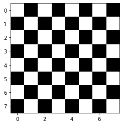

```python
import matplotlib.pyplot as plt
dim = 8    # dimension of th eplot

checker = [[0 if (i+j)%2 else 255 for i in range(dim)] for j in range(dim)]
print(checker)

plt.imshow(checker, cmap='gray')
plt.show()
```